# PA1_template

– Parts 2 & 3  
Fill in missing data.

```r
dailyMean <- activity_df %>%
        fill(steps, .direction = "up") %>%
        fill(steps, .direction = "down")
summary(activity_df$steps)
```

```
##    Min. 1st Qu.  Median    Mean 3rd Qu.    Max.    NA's
##    0.00    0.00    0.00   37.38   12.00  806.00    2304
```

```r
summary(dailyMean$steps)
```

```
##    Min. 1st Qu.  Median    Mean 3rd Qu.    Max.
##    0.00    0.00    0.00   32.48    0.00  806.00
```

– Part 4  
Sum steps by day

```r
dailyMean_df <- dailyMean %>%
        select(steps, date) %>%
        group_by(date) %>%
        summarize(totalDaily = sum(steps))
```

Histogram of total # of steps each day

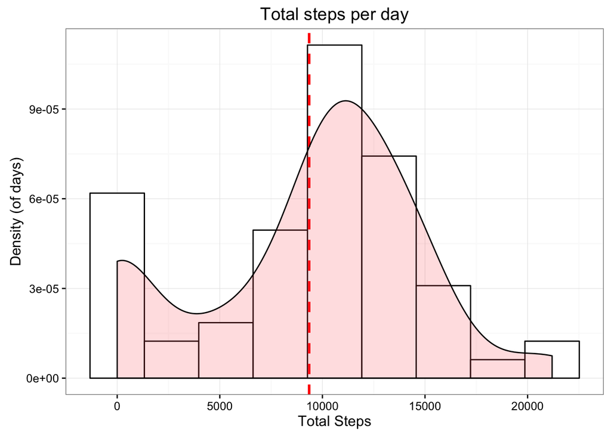

```r
dmeanHisto <- ggplot(dailyMean_df, aes(totalDaily)) +
                    geom_histogram(
                            aes(y=..density..),
                            bins = 9,
                            colour = "black",
                            fill = "white") +
                    coord_cartesian() +
                    ggtitle("Total steps per day")+
                    xlab("Total Steps") +
                    ylab("Density (of days)") +
                    theme_bw() +
                    geom_vline(aes(xintercept =mean(totalDaily)),
                            color = "red",
                            linetype = "dashed",
                            size = 1) +
                    geom_density(
                            alpha = .2,
                            fill = "#FF6666")

dmeanHisto
```

Reporting the mean and median total number of steps taken per day:

```r
summary(dailyMean_df$totalDaily)
```

```
##    Min. 1st Qu.  Median    Mean 3rd Qu.    Max.
##       0    6778   10400    9354   12810   21190
```

**Are there differences in activity patterns between weekdays & weekends?**

Create new factors “weekend” & “weekday” using the dataset dailyMean(dataset with filled in values)

```r
fullWeek_df <- dailyMean
fullWeek_df$dayOfWeek <- weekdays(strptime(fullWeek_df$date, format = "%Y-%m-%d"))
fullWeek_df_copy <- fullWeek_df %>%
        mutate(dayOfWeekFactors = factor(1*(dayOfWeek == "Saturday" | dayOfWeek == "Sunday"), labels = c("weekday", "weekend")))

str(fullWeek_df_copy)
```

```
## Classes 'tbl_df', 'tbl' and 'data.frame':    17568 obs. of  5 variables:
##  $ steps           : int  0 0 0 0 0 0 0 0 0 0 ...
##  $ date            : Date, format: "2012-10-01" "2012-10-01" ...
##  $ interval        : num  0 5 10 15 20 25 30 35 40 45 ...
##  $ dayOfWeek       : chr  "Monday" "Monday" "Monday" "Monday" ...
##  $ dayOfWeekFactors: Factor w/ 2 levels "weekday","weekend": 1 1 1 1 1 1 1 1 1 1 ...
```

```r
glimpse(fullWeek_df_copy)
```

```
## Observations: 17,568
## Variables: 5
## $ steps            <int> 0, 0, 0, 0, 0, 0, 0, 0, 0, 0, 0, 0, 0, 0, 0, ...
## $ date             <date> 2012-10-01, 2012-10-01, 2012-10-01, 2012-10-...
## $ interval         <dbl> 0, 5, 10, 15, 20, 25, 30, 35, 40, 45, 50, 55,...
## $ dayOfWeek        <chr> "Monday", "Monday", "Monday", "Monday", "Mond...
## $ dayOfWeekFactors <fctr> weekday, weekday, weekday, weekday, weekday,...
```

To calibrate factors for charting

```r
weekdayMeanSteps <- fullWeek_df_copy %>%
        filter(dayOfWeekFactors =="weekday") %>%
        group_by(interval = factor(interval)) %>%
        summarise(date = "weekday", meanStep = mean(steps))
weekendMeanSteps <- fullWeek_df_copy %>%
        filter(dayOfWeekFactors =="weekend") %>%
        group_by(interval = factor(interval)) %>%
        summarise(date = "weekend", meanStep = mean(steps))
weekFactors <- rbind(weekdayMeanSteps, weekendMeanSteps)
```

Panel plot

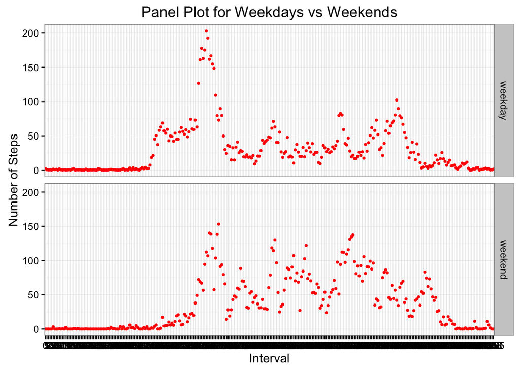

```r
panelPlot <- ggplot(weekFactors, aes(interval, meanStep))+
        geom_point(color = "red",
                   size = 0.75) +
        facet_grid(date ~.) +
        ggtitle("Panel Plot for Weekdays vs Weekends") +
        xlab("Interval") +
        ylab("Number of Steps") +
        theme_bw()
panelPlot
```